# **Bilgi Yönetim Sistemleri - Bitirme Projesi Rapor** *Abdulkadir Gür 190401046* *Hatice Sudenas Çapacı 190401034* *Mert Pamuk 200401056* *Mustafa Koçer 200401030* *Yusuf Talha Kaya 200401042*

Q1 İş Problemi

**E-ticaret sektöründe faaliyet gösteren FECR-I ATI firması**, müşteri memnuniyetini artırmak ve satışları maksimize etmek amacıyla iş süreçlerini ve pazarlama stratejilerini optimize etmek istemektedir. Bu bağlamda, **WordPress** platformunu kullanarak veri analizleri ve müşteri etkileşimleri üzerinden kişiselleştirilmiş pazarlama stratejileri geliştirilecektir.

İlk bulduğumuz veri setinde ürünler ile satış verilerindeki ürünlerin ID’leri uyuşmadığı ve doğru bir analiz yapamayacağımız için veri setini değiştirmek zorunda kaldık.

Projemizde, içerik yönetim sistemi olarak **WordPress** kullanılmaktadır. WordPress’in tercih edilme sebepleri, kullanım kolaylığı, geniş eklenti desteği, güçlü topluluk desteği ve esnek yapısıdır.

### WordPress’i Özel Kılan Özellikler

- **Tema Desteği**: Geniş tema kütüphanesi ile site tasarımı kolayca özelleştirilebilir.
- **Eklenti Mimarisi**: 50,000’den fazla eklenti ile işlevsellik artırılabilir (örneğin, **WooCommerce** eklentisi).
- **SEO Optimizasyonu**: SEO dostu yapısı ve çeşitli SEO eklentileri ile arama motorlarında daha üst sıralara çıkmak mümkündür.
- **REST API Desteği**: Verilerin başka uygulamalara entegre edilmesi ve analiz yapılması sağlanır.
- **Kullanıcı ve Rol Yönetimi**: Farklı yetkilerle kullanıcı hesapları oluşturulabilir.
- **Medya Yönetimi**: Görsel ve video dosyaları kolayca yüklenip yönetilebilir.
- **Çoklu Dil Desteği**: WPML gibi eklentiler ile çok dilli siteler oluşturulabilir.

### İş Süreçlerinde Yararlanılacak Özellikler

- **Veri İthalatı**: Müşteri ve sipariş bilgileri için **WooCommerce REST API**, ürün bilgileri için ise WooCommerce Ürün sekmesi kullanılarak WooCommerce aracılığıyla ithal edilecektir. Verilerin doğru şekilde aktarıldığı test edildikten sonra analiz süreci başlayacaktır.
- **Verilerin Çekilmesi**: **WooCommerce REST API** kullanılarak ürün, sipariş ve müşteri verileri çekilecektir. Bu API, verilerin programlı şekilde yönetilmesine ve diğer uygulamalarla entegrasyonuna imkan tanır.

Q2 İş Problemi Çözmede Kullanılacak Data Seti

Kaynak: [Bigquery Dataset](https://www.kaggle.com/datasets/mustafakeser4/looker-ecommerce-bigquery-dataset)

## “users.csv” Verisi

### Verinin Kaynağı

Veri seti, çeşitli ülkelerden kullanıcı bilgilerini içeren bir veri kümesidir. Veriyi oluşturan kişiler, çeşitli demografik bilgiler, adres bilgileri ve kullanıcı aktiviteleri gibi bilgileri içeren bir veri kümesi oluşturmuştur.

### Veri Setinin İçeriği

*Genel Bakış:* Bu veri seti, 2000 satır ve 15 sütundan oluşmaktadır.

Veri seti şu sütunlardan oluşmaktadır:

- id: Kullanıcı ID’si
- first_name: Kullanıcının adı
- last_name: Kullanıcının soyadı
- email: Kullanıcının e-posta adresi
- age: Kullanıcının yaşı
- gender: Kullanıcının cinsiyeti
- state: Kullanıcının yaşadığı eyalet/bölge
- street_address: Kullanıcının sokak adresi
- postal_code: Kullanıcının posta kodu
- city: Kullanıcının yaşadığı şehir
- country: Kullanıcının yaşadığı ülke
- latitude: Kullanıcının coğrafi enlemi
- longitude: Kullanıcının coğrafi boylamı
- traffic_source: Kullanıcının geldiği trafik kaynağı
- created_at: Kullanıcının oluşturulma tarihi ve saati

### Veri Setinde Yapılan Değişiklikler

Bu veri setinde “longitude” ve “latitude” sütunları uygulamamız için gerekli olmaması ve eksik veri barındırması sebebiyle silindi ve eksik olan yerler “NA” değeri ile dolduruldu.

## “orders.csv” Verisi

### Verinin Kaynağı

Veri seti, e-ticaret işlemlerini içeren bir veri kümesidir. Bu veri seti, örnek satış siparişlerini ve kullanıcı bilgilerini içermektedir.

### Veri Setinin İçeriği

*Genel Bakış:* Bu veri seti, 2479 satır ve 9 sütundan oluşmaktadır.

Veri seti şu sütunlardan oluşmaktadır:

- order_id: Siparişin benzersiz kimliği
- user_id: Kullanıcının benzersiz kimliği
- status: Siparişin durumu (Shipped, Complete, Processing)
- gender: Kullanıcının cinsiyeti
- created_at: Siparişin oluşturulma tarihi ve saati
- returned_at: Ürün iadesi tarihi ve saati
- shipped_at: Ürünün sevkiyat tarihi ve saati
- delivered_at: Ürünün teslim tarihi ve saati
- num_of_item: Siparişteki ürün miktarı

### Veri Setinde Yapılan Değişiklikler

Bu veri setinde “returned_at”,“shipped_at”,“delivered_at” sütunları uygulamamız için gerekli olmaması ve eksik veri barındırması sebebiyle silindi ve eksik olan yerler “NA” değeri ile dolduruldu.

## “order_items.csv” Verisi

### Verinin Kaynağı

Bu veri seti, e-ticaret işlemlerini içeren bir başka örnek veri kümesidir. Siparişlerin detaylarını ve ürün bilgilerini içermektedir.

### Veri Setinin İçeriği

*Genel Bakış:* Bu veri seti, 3591 satır ve 11 sütundan oluşmaktadır.

Veri seti şu sütunlardan oluşmaktadır:

- id: Sipariş kaleminin benzersiz kimliği
- order_id: Siparişin benzersiz kimliği
- user_id: Kullanıcının benzersiz kimliği
- product_id: Ürünün benzersiz kimliği
- inventory_item_id: Stok kaleminin benzersiz kimliği
- status: Siparişin durumu (Shipped, Complete, Processing)
- created_at: Sipariş kaleminin oluşturulma tarihi ve saati
- shipped_at: Sipariş kaleminin sevkiyat tarihi ve saati
- delivered_at: Sipariş kaleminin teslim tarihi ve saati
- returned_at: Sipariş kaleminin iade tarihi ve saati
- sale_price: Ürünün satış fiyatı

### Veri Setinde Yapılan Değişiklikler

Bu veri setinde “returned_at”,“shipped_at”,“delivered_at” sütunları uygulamamız için gerekli olmaması ve eksik veri barındırması sebebiyle silindi , eksik olan yerler “NA” değeri ile dolduruldu.

## “products.csv” Verisi

### Verinin Kaynağı

Veri seti, çeşitli kategorilerdeki ürün bilgilerini içeren bir veri kümesidir. Veriyi oluşturan kişiler, ürün maliyeti, kategori, marka, perakende fiyatı ve dağıtım merkezi bilgilerini içeren bir veri kümesi oluşturmuştur.

### Veri Setinin İçeriği

Veri seti şu sütunlardan oluşmaktadır:

Q3 Veri seti keşifsel analizi

#### Kütüphaneleri Yükleme:

- `tidyverse`, `magrittr`, ve `dplyr` kütüphaneleri yüklenir. Bu kütüphaneler veri manipülasyonu ve analizi için kullanılır.

#### CSV Dosyasını Yükleme:

- `load_data` fonksiyonu, CSV dosyasının yolunu ve ayırıcı karakteri alır ve veri çerçevesini döndürür. Bu fonksiyon `read.csv` fonksiyonunu kullanır.

#### Veriye Genel Bakış ve Eksik Verileri Kontrol Etme:

- `summarize_data` fonksiyonu, veri çerçevesini alır ve genel bir bakış sağlar.

#### Eksik Verileri Doldurma veya Çıkarma:

- `handle_missing_data` fonksiyonu, veri çerçevesini alır ve eksik verileri işler. Karakter dizilerindeki boş değerleri `NA` ile değiştirir ve sayısal sütunlardaki `NA` değerlerini sütun ortalaması ile doldurur.

#### Gereksiz Kolonları Kaldırma:

- `remove_unnecessary_columns` fonksiyonu, veri çerçevesini ve kaldırılacak sütunların isimlerini alır, ve belirtilen sütunları kaldırarak veri çerçevesini döndürür.

#### Veri Çerçevesini CSV Dosyasına Kaydetme:

- `save_data` fonksiyonu, veri çerçevesini CSV dosyasına kaydeder. Bu fonksiyon `write.csv` fonksiyonunu kullanır.

#### Ana İşlem Fonksiyonu:

- `process_data` fonksiyonu, giriş CSV dosyasının yolunu, çıkış CSV dosyasının yolunu, ayırıcı karakteri ve kaldırılacak sütunların isimlerini alır. Bu fonksiyon, veri yükleme, eksik veri işleme, gereksiz sütunları kaldırma ve sonuçları kaydetme adımlarını içerir.

```
## Users Data
```

```
## Veri çerçevesinin boyutu: 2000 satır, 16 sütun
##
## Sütun isimleri: id, first_name, last_name, email, age, gender, state, street_address, postal_code, city, country, latitude, longitude, traffic_source, created_at, X
##
## Her sütundaki eksik değer sayısı:
##             id     first_name      last_name          email            age
##              0              0              0              0              0
##         gender          state street_address    postal_code           city
##              0              0              0              0              0
##        country       latitude      longitude traffic_source     created_at
##              0              0              0              0              0
##              X
##           2000
##
## Veri ön işleme yaptıktan sonra veriler:
##
## Veri çerçevesinin boyutu: 2000 satır, 13 sütun
##
## Sütun isimleri: id, first_name, last_name, email, age, gender, state, street_address, postal_code, city, country, traffic_source, created_at
##
## Her sütundaki eksik değer sayısı:
##             id     first_name      last_name          email            age
##              0              0              0              0              0
##         gender          state street_address    postal_code           city
##              0              0              0              0              0
##        country traffic_source     created_at
##              0              0              0
```

```
## Orders Data
```

```
## Veri çerçevesinin boyutu: 2479 satır, 9 sütun
##
## Sütun isimleri: order_id, user_id, status, gender, created_at, returned_at, shipped_at, delivered_at, num_of_item
##
## Her sütundaki eksik değer sayısı:
##     order_id      user_id       status       gender   created_at  returned_at
##            0            0            0            0            0            0
##   shipped_at delivered_at  num_of_item
##            0            0            0
##
## Veri ön işleme yaptıktan sonra veriler:
##
## Veri çerçevesinin boyutu: 2479 satır, 6 sütun
##
## Sütun isimleri: order_id, user_id, status, gender, created_at, num_of_item
##
## Her sütundaki eksik değer sayısı:
##    order_id     user_id      status      gender  created_at num_of_item
##           0           0           0           0           0           0
```

```
## Order Items Data
```

```
## Veri çerçevesinin boyutu: 3591 satır, 11 sütun
##
## Sütun isimleri: id, order_id, user_id, product_id, inventory_item_id, status, created_at, shipped_at, delivered_at, returned_at, sale_price
##
## Her sütundaki eksik değer sayısı:
##                id          order_id           user_id        product_id
##                 0                 0                 0                 0
## inventory_item_id            status        created_at        shipped_at
##                 0                 0                 0                 0
##      delivered_at       returned_at        sale_price
##                 0                 0                 0
##
## Veri ön işleme yaptıktan sonra veriler:
##
## Veri çerçevesinin boyutu: 3591 satır, 7 sütun
##
## Sütun isimleri: id, order_id, user_id, product_id, inventory_item_id, status, created_at
##
## Her sütundaki eksik değer sayısı:
##                id          order_id           user_id        product_id
##                 0                 0                 0                 0
## inventory_item_id            status        created_at
##                 0                 0                 0
```

```
## Product Data
```

```
## Veri çerçevesinin boyutu: 3684 satır, 8 sütun
##
## Sütun isimleri: id, category, name, brand, retail_price, department, sku, distribution_center_id
##
## Her sütundaki eksik değer sayısı:
##                     id               category                   name
##                      0                      0                      0
##                  brand           retail_price             department
##                      3                      0                      0
##                    sku distribution_center_id
##                      0                      0
##
## Veri ön işleme yaptıktan sonra veriler:
##
## Veri çerçevesinin boyutu: 3684 satır, 8 sütun
##
## Sütun isimleri: id, category, name, brand, retail_price, department, sku, distribution_center_id
##
## Her sütundaki eksik değer sayısı:
##                     id               category                   name
##                      0                      0                      0
##                  brand           retail_price             department
##                      3                      0                      0
##                    sku distribution_center_id
##                      0                      0
```

```
## Graphics
```

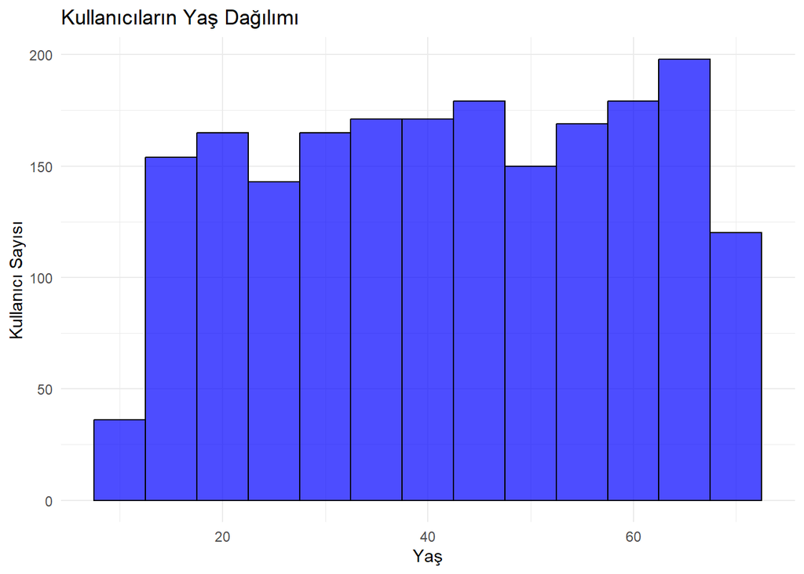

#### Bu grafik kullanıcıların yaş dağılımını göstermektedir.Böylece e-ticaret sitemizin yaş kitlesini görebilmekteyiz.

Q4 Veri setinin BYS platformuna ithali

## Veri İthalatı

**Users ve order ve order_items** bilgileri için **WooCommerce REST API**, **product** bilgileri için ise WooCommerce ürün sekmesi kullanılarak WooCommerce aracılığıyla ithal edildi.

**R Api Script kodları adresi:**

- `Fecriati/R/Api_operations`

Q5: Yapılması Planlanan Veri Analizi

#### **Veri Birleştirme**

İlk adım olarak, *“users.csv”*, *“orders.csv”* ve *“order_items.csv”* verilerini *“user_id”* veya *“order_id”* gibi **benzersiz bir kimlik** ile birleştirerek zengin bir içerik oluşturulacak.

Veri birleştirme işlemi, müşteri bilgileri ile sipariş bilgilerini bir araya getirerek daha **kapsamlı bir veri seti** oluşturmamıza imkan sağlayacak. Bu, müşteri segmentasyonu, kişiselleştirilmiş pazarlama stratejileri ve müşteri sadakati gibi konuları daha iyi anlamanıza yardımcı olabilir.

#### **Müşteri Satın Alma Alışkanlıklarının Analizi**

Müşteri satın alma alışkanlıklarını analiz etmek için, ürün satış verilerini kullanacağız. Hangi ürünlerin en çok satıldığını ve hangi müşteri segmentlerinin hangi ürünleri tercih ettiğini belirlemek için satış verilerini **görselleştirecek** ve analiz edeceğiz.

#### **Coğrafi Konuma Göre Satışların İncelenmesi**

Coğrafi konuma göre satışları incelemek için *“country”* veya *“city”* sütunlarını kullanarak, verileri belirli **kategorilere veya segmentlere** ayıracağız.

Belirlediğimiz kategorilere göre verileri **gruplayarak** analiz edebileceğiz. Örneğin, her bir ülkeye veya şehre göre toplam satış miktarını analiz edeceğiz. Bu analiz sonucunda coğrafi konumun satışlarımız üzerindeki olumsuz etkilerini tespit edip bu soruna çözüm bulabileceğiz.

Q6: Çalışan Platformun Gösterildiği Sesli Anlatımlı Video

**YouTube Linki:** https://youtu.be/R6jxV_tuwF4

## Açıklama

Bu bölümde, çalışan platformun nasıl çalıştığını gösteren bir video bulunmaktadır. Video, platformun ana işlevlerini ve kullanıcı arayüzünü detaylı bir şekilde anlatmaktadır.

Q7: Final Analizi

Bu bölümde belirlediğimiz analizleri yapacağız.

[output not shown]

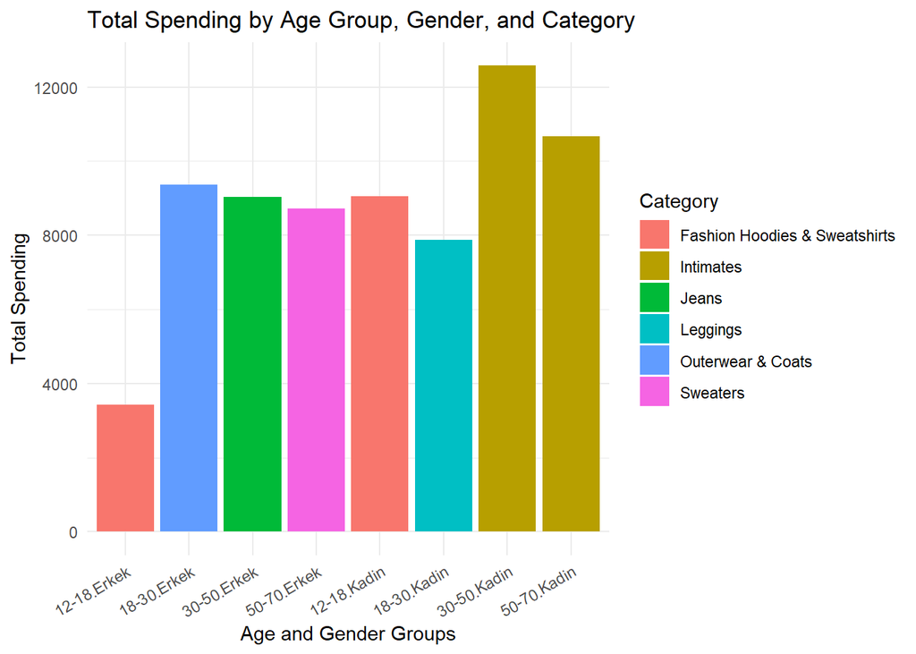

[output not shown]

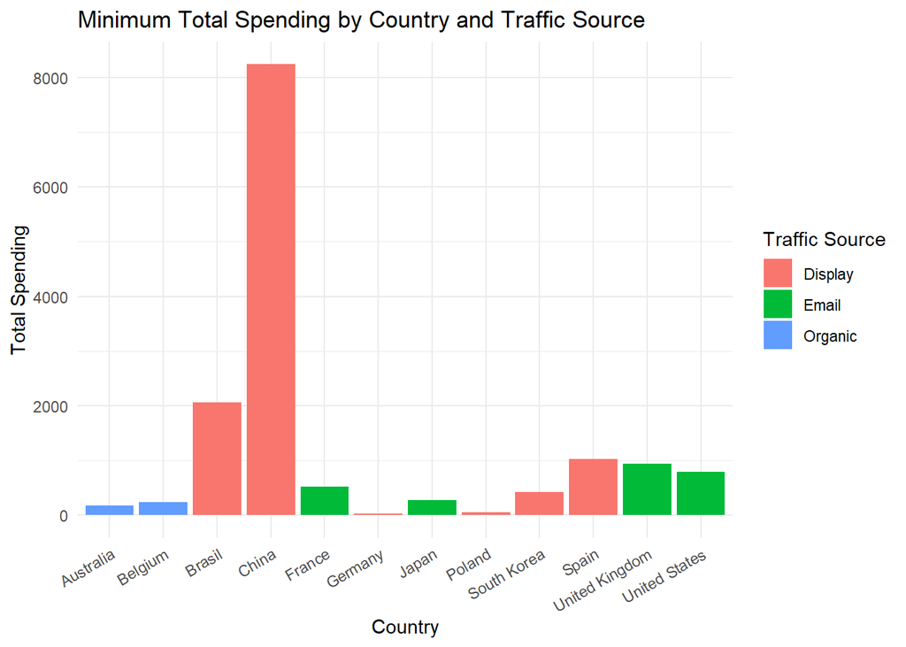